# Модуль 1. Розділ 4. Лабораторна робота №3. Розвідувальний аналіз даних. Візуалізація

Barbir Vladyslav

2025-10-14

**Мета:** *Засвоєння принципів, знайомство з інструментами та набуття навичок експлораторного (розвідувального) аналізу даних засобами мови програмування R та колекції пакетів dplyr, ggplot2, desctable, “GGally”, “corrplot”, “PerformanceAnalytics”, “FactoMineR”, “factoextra”, “funModeling”, “desctable”, “ade4”, “psych”, “smacof”, “WVPlots”, “caret”, “car”.*.

## Хід роботи

Дано багатовимірний набір даних PimaIndiansDiabetes. Цей датасет походить від Національного інституту діабету, хвороб травлення та нирок і містить дані про 768 жінок племені Піма віком від 21 року. Метою дослідження є прогнозування появи діабету на основі певних діагностичних вимірювань.

Для даного набору виконати розвідувальний аналіз даних. Необхідно дати відповідь на такі питання:

```
чи є дані комплектними? з'ясувати характер розподілу змінних.

чи пов'язані між собою характеристики? якщо пов'язані, то які і як?

чи існує проста структура, яка дозволяє описати дані об'єкти в просторі розмірністю менш ніж 8? якщо існує -- побудувати таку модель.

чи є групи пацієнтів (з діабетом та без) однорідними у даному просторі ознак? якщо ні, то виконати сегментацію -- знайти групи з однорідними ознаками.
```

Результати представити із застосуванням простих і зрозумілих візуалізаторів.

### Виконання завдання

Дані з досліджуваного набору мають наступний вигляд:

```r
library(mlbench)
library(tibble)

data(PimaIndiansDiabetes)
diabetes_orig <- as_tibble(PimaIndiansDiabetes)

diabetes_orig |>
  head()
```

| pregnant | glucose | pressure | triceps | insulin | mass | pedigree | age | diabetes |
| --- | --- | --- | --- | --- | --- | --- | --- | --- |
| 6 | 148 | 72 | 35 | 0 | 33.6 | 0.627 | 50 | pos |
| 1 | 85 | 66 | 29 | 0 | 26.6 | 0.351 | 31 | neg |
| 8 | 183 | 64 | 0 | 0 | 23.3 | 0.672 | 32 | pos |
| 1 | 89 | 66 | 23 | 94 | 28.1 | 0.167 | 21 | neg |
| 0 | 137 | 40 | 35 | 168 | 43.1 | 2.288 | 33 | pos |
| 5 | 116 | 74 | 0 | 0 | 25.6 | 0.201 | 30 | neg |

Обчислимо і дослідимо сумарні статистики.

```r
diabetes_orig |>
  summary()
```

```
##     pregnant         glucose         pressure         triceps
##  Min.   : 0.000   Min.   :  0.0   Min.   :  0.00   Min.   : 0.00
##  1st Qu.: 1.000   1st Qu.: 99.0   1st Qu.: 62.00   1st Qu.: 0.00
##  Median : 3.000   Median :117.0   Median : 72.00   Median :23.00
##  Mean   : 3.845   Mean   :120.9   Mean   : 69.11   Mean   :20.54
##  3rd Qu.: 6.000   3rd Qu.:140.2   3rd Qu.: 80.00   3rd Qu.:32.00
##  Max.   :17.000   Max.   :199.0   Max.   :122.00   Max.   :99.00
##     insulin           mass          pedigree           age        diabetes
##  Min.   :  0.0   Min.   : 0.00   Min.   :0.0780   Min.   :21.00   neg:500
##  1st Qu.:  0.0   1st Qu.:27.30   1st Qu.:0.2437   1st Qu.:24.00   pos:268
##  Median : 30.5   Median :32.00   Median :0.3725   Median :29.00
##  Mean   : 79.8   Mean   :31.99   Mean   :0.4719   Mean   :33.24
##  3rd Qu.:127.2   3rd Qu.:36.60   3rd Qu.:0.6262   3rd Qu.:41.00
##  Max.   :846.0   Max.   :67.10   Max.   :2.4200   Max.   :81.00
```

Що ми бачимо?

[output not shown]

Дослідимо закони розподілу кожної з восьми змінних. Для цього побудуємо гістограми для кожної з числових змінних.

```r
library(tidyverse)
```

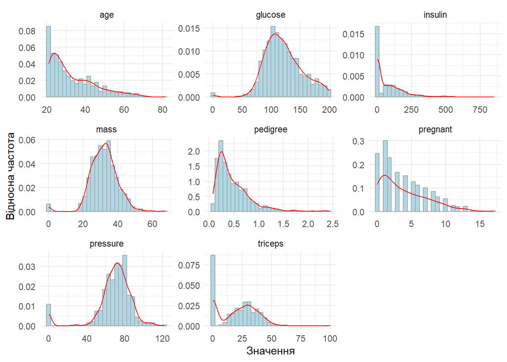

```r
diabetes_orig |>
  select(-diabetes) |>
  pivot_longer(cols = everything()) |>
  ggplot(aes(x = value)) +
  geom_histogram(aes(y = after_stat(density)),
                 fill = "lightblue",
                 color = "dark grey",
                 bins = 30) +
  geom_density(color = "red") +
  facet_wrap(~name, scales = "free") +
  theme_minimal() +
  labs(x = "Значення", y = "Відносна частота")
```

Що ми бачимо?

```
Розподіли змінних glucose та pressure нагадують дзвоноподібну форму, що є близькою до нормального розподілу, хоча й з деякою асиметрією. Наявність нулів дещо спотворює ці розподіли.

Розподіли змінних pregnant, insulin, triceps, pedigree, та age є сильно асиметричними (скошеними вправо). Це вказує на те, що більшість спостережень мають низькі значення цих показників, але існують і значно вищі, хоча й рідкісні, значення.

Висока частота нульових значень для insulin та triceps підтверджує припущення, що це, ймовірно, закодовані пропущені дані.
```

Для відповіді на питання, чи пов’язані між собою змінні, застосуємо кореляційний аналіз. З урахуванням числової природи даних, для оцінки кореляції скористаємося коефіцієнтом кореляції Пірсона.

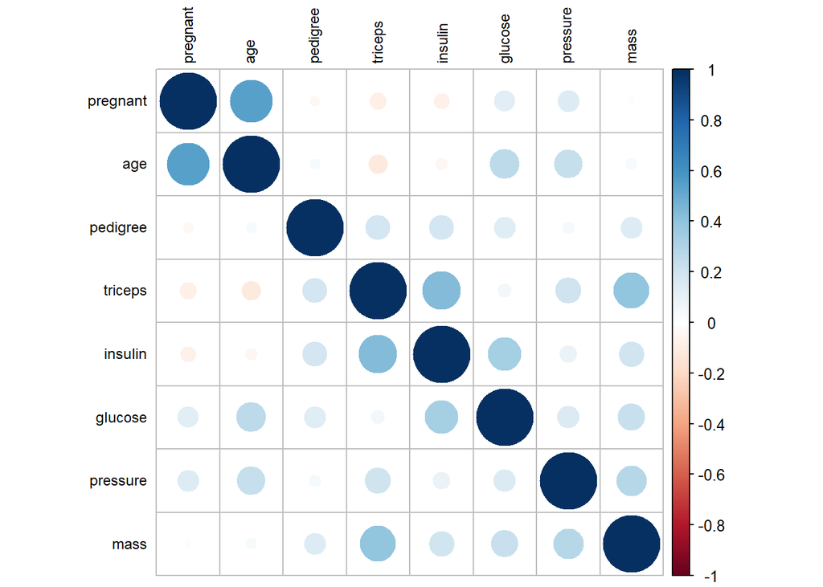

```r
library(corrplot)
diabetes_orig |>
  select(-diabetes) |>
  cor() |>
  corrplot(order = "hclust", tl.col='black', tl.cex=.75)
```

Також побудуємо матрицю діаграм розсіювання, щоб візуально оцінити зв’язки між змінними, розфарбувавши точки відповідно до наявності діабету.

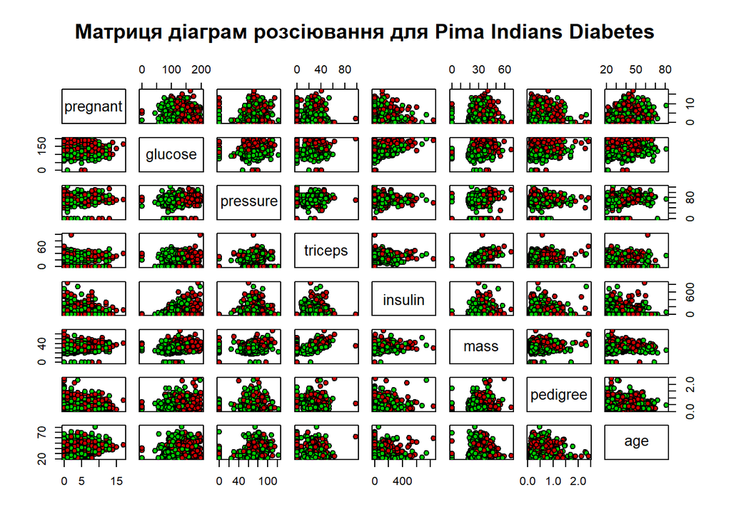

```r
pairs(diabetes_orig |> select(-diabetes),
      main="Матриця діаграм розсіювання для Pima Indians Diabetes",
      pch=21,
      bg=c("green3", "red3")[unclass(diabetes_orig$diabetes)])
```

Що ми бачимо?

```
Існує помітний позитивний кореляційний зв'язок між змінними:

    age та pregnant (вік та кількість вагітностей) — що є логічним.

    mass та triceps (індекс маси тіла та товщина шкірної складки).

    glucose та insulin (рівень глюкози та інсуліну).

На кореляційних полях видно, що групи пацієнтів з діабетом (red3) та без (green3) частково перекриваються, але мають різні центри розподілу. Наприклад, на діаграмі glucose проти age видно, що пацієнти з діабетом частіше мають вищі показники глюкози в будь-якому віці.

Слабкі кореляції між іншими змінними свідчать про те, що вони несуть унікальну інформацію.
```

Наявність кореляцій дає підстави припустити, що можна знизити розмірність простору ознак. Для цього скористаємося методом головних компонент (PCA).

```r
library(FactoMineR)
library(factoextra)
```

```r
resPCA <- diabetes_orig |>
  select(-diabetes) |>
  PCA(graph = FALSE, scale.unit = TRUE)
```

```r
eigenvalues <- as.data.frame(resPCA$eig)
knitr::kable(
  eigenvalues,
  caption = "Власні значення (eigenvalues) і сумарний процент поясненої дисперсії"
)
```

Власні значення (eigenvalues) і сумарний процент поясненої дисперсії

|  | eigenvalue | percentage of variance | cumulative percentage of variance |
| --- | --- | --- | --- |
| comp 1 | 2.0943799 | 26.179749 | 26.17975 |
| comp 2 | 1.7312101 | 21.640127 | 47.81988 |
| comp 3 | 1.0296299 | 12.870373 | 60.69025 |
| comp 4 | 0.8755290 | 10.944113 | 71.63436 |
| comp 5 | 0.7623444 | 9.529305 | 81.16367 |
| comp 6 | 0.6826284 | 8.532855 | 89.69652 |
| comp 7 | 0.4198162 | 5.247702 | 94.94422 |
| comp 8 | 0.4044620 | 5.055776 | 100.00000 |

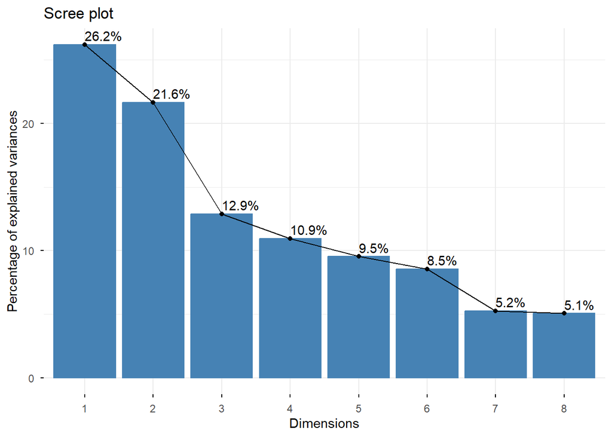

```r
fviz_screeplot(resPCA, addlabels = TRUE)
```

```r
knitr::kable(
  resPCA$var$coord[, 1:2],
  caption = "Таблиця навантажень"
)
```

Таблиця навантажень

|  | Dim.1 | Dim.2 |
| --- | --- | --- |
| pregnant | 0.1858666 | 0.7812764 |
| glucose | 0.5688680 | 0.2289796 |
| pressure | 0.5209948 | 0.2419568 |
| triceps | 0.6365125 | -0.4367849 |
| insulin | 0.6295687 | -0.3299663 |
| mass | 0.6540483 | -0.1328383 |
| pedigree | 0.3916281 | -0.1606129 |
| age | 0.2865842 | 0.8165422 |

Що ми бачимо?

[output not shown]

Тепер візуалізуємо пацієнтів у просторі перших двох головних компонент, щоб побачити, чи утворюють вони окремі кластери.

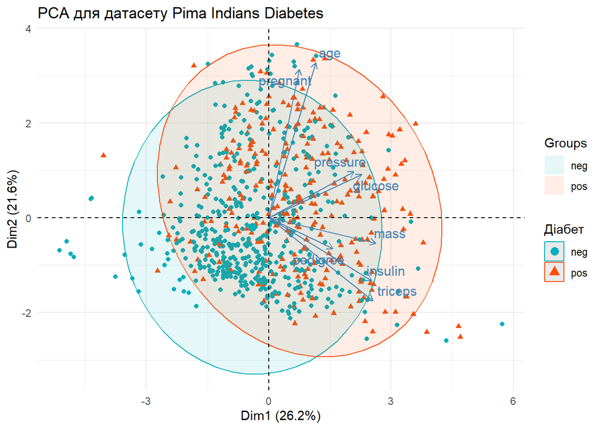

```r
fviz_pca_biplot(resPCA,
                geom = "point",
                habillage = diabetes_orig$diabetes,
                addEllipses = TRUE,
                ellipse.level = 0.95,
                palette = c("#00AFBB", "#FC4E07"),
                repel = TRUE) +
  theme_minimal() +
  labs(title = "PCA для датасету Pima Indians Diabetes",
       color = "Діабет",
       shape = "Діабет")
```

## References

1. James, G., Witten, D., Hastie, T., & Tibshirani, R. (2023). *An Introduction to Statistical Learning: with Applications in R (3rd ed.)*. Springer.
2. Wickham, H., & Grolemund, G. (2017). *R for Data Science: Import, Tidy, Transform, Visualize, and Model Data*. O’Reilly Media.
3. Kuhn, M., & Silge, J. (2022). *Tidy Modeling with R*. O’Reilly Media.
4. Han, J., Pei, J., & Kamber, M. (2022). *Data Mining: Concepts and Techniques (4th ed.)*. Morgan Kaufmann.